# demonstration

Thijs Janzen

2025-10-27

```r
knitr::opts_chunk$set(echo = TRUE, fig.width = 7)

library(simRestore)
library(ggplot2)
library(magrittr)
library(tidyr)
library(dplyr)
```

# Using simRestore

simRestore is an R package designed to aid in making management decisions to restore a population back to a target genetic ancestry. For this, several tools are available within the package. Let’s first explore our imaginary focal system of interest

## Simulating

simRestore simulates a population forward in time, subject to management intervention. Without intervention, simRestore assumes overlapping generations, density dependent survival and random mating. We can simulate such a population as follows:

```r
sim_pop <- simulate_policy(initial_population_size = 100,
                           num_generations = 20,
                           starting_freq = 0.2,
                           K = 400)
```

This returns a large tibble, and we can use that to plot several characteristics:

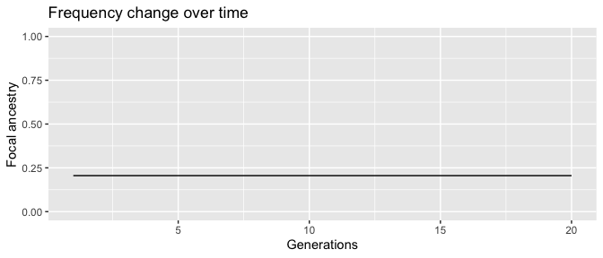

```r
ggplot(sim_pop$results, aes(x = t, y = freq_focal_ancestry)) +
  geom_line() +
  ylim(0, 1) +
  ggtitle("Frequency change over time") +
  xlab("Generations") +
  ylab("Focal ancestry")
```

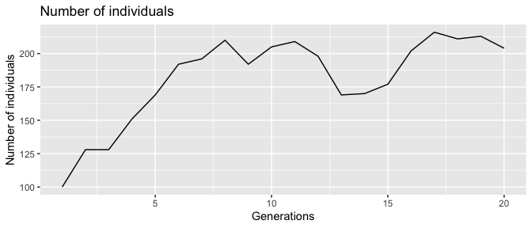

```r
ggplot(sim_pop$results, aes(x = t, y = num_individuals)) +
  geom_line() +
  ggtitle("Number of individuals") +
  xlab("Generations") +
  ylab("Number of individuals")
```

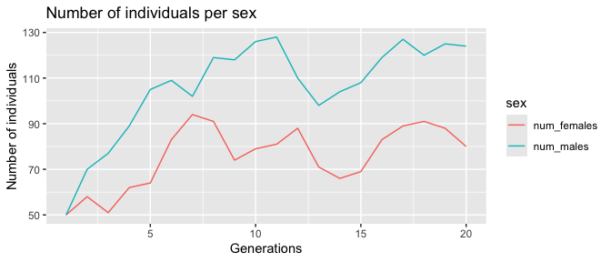

```r
sim_pop$results %>%
  gather(key = "sex", value = "num_indiv", c(num_males, num_females)) %>%
  ggplot(aes(x = t, y = num_indiv, col = sex)) +
    geom_line() +
    ggtitle("Number of individuals per sex") +
    xlab("Generations") +
    ylab("Number of individuals")
```

We observe that the population grows over time, but at the same time, the target frequency does not change. We can modify this by making interventions: putting and pulling. In putting, we add individuals with 100% focal ancestry to the population, in pulling, we remove individuals randomly from the population. We’ll first simulate pulling:

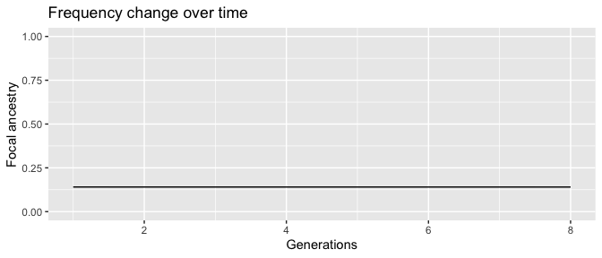

```r
sim_pop <- simulate_policy(initial_population_size = 100,
                           num_generations = 20,
                           pull = 20,
                           starting_freq = 0.2,
                           K = 400)
ggplot(sim_pop$results, aes(x = t, y = freq_focal_ancestry)) +
  geom_line() +
  ylim(0, 1) +
  ggtitle("Frequency change over time") +
  xlab("Generations") +
  ylab("Focal ancestry")
```

Because pulling happens at random, the average frequency does not change. When we add individuals however, we do see a genetic response:

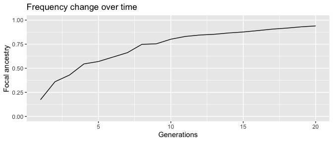

```r
sim_pop <- simulate_policy(initial_population_size = 100,
                           num_generations = 20,
                           put = 20,
                           starting_freq = 0.2,
                           K = 400)
ggplot(sim_pop$results, aes(x = t, y = freq_focal_ancestry)) +
  geom_line() +
  ylim(0, 1) +
  ggtitle("Frequency change over time") +
  xlab("Generations") +
  ylab("Focal ancestry")
```

Clearly, putting does move the needle, and in this case in a positive way! We can even modify the ancestry of individuals we are adding, in case we do not have access to individuals with high focal ancestry, or if we are targeting another ancestry level:

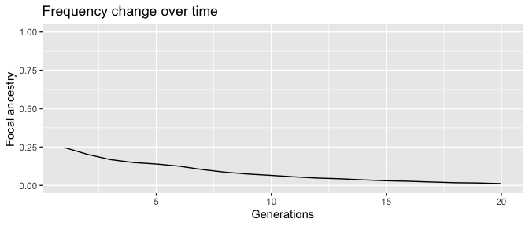

```r
sim_pop <- simulate_policy(initial_population_size = 100,
                           num_generations = 20,
                           put = 20,
                           K = 400,
                           starting_freq = 0.2,
                           ancestry_put = 0.0)
ggplot(sim_pop$results, aes(x = t, y = freq_focal_ancestry)) +
  geom_line() +
  ylim(0, 1) +
  ggtitle("Frequency change over time") +
  xlab("Generations") +
  ylab("Focal ancestry")
```

# Optimization

To explore potential remedies, simRestore includes two optimization procedures to find the ideal management strategy, depending on the target required. In doing so, simRestore tries to find the minimal effort required to obtain the required target.

## Static optimization

In static optimization, simRestore tries to find a fixed number of individuals to be put or pulled per generation in order to reach the obtained target frequency. For instance, if we want to reach 0.99 ancestry within 20 generations:

```r
opt_res <- optimize_static(target_frequency = 0.99,
                           optimize_put = TRUE,
                           num_generations = 20,
                           starting_freq = 0.2,
                           initial_population_size = 100)
opt_res$put
```

```
## [1] 99
```

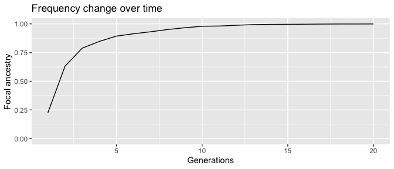

```r
ggplot(opt_res$results,
       aes(x = t, y = freq_focal_ancestry)) +
  geom_line() +
  ylim(0, 1) +
  ggtitle("Frequency change over time") +
  xlab("Generations") +
  ylab("Focal ancestry")
```

## Adaptive optimization

Adding individuals perhaps works better in the first few generations, compared to the last few. Instead, therefore, the user can opt to estimate the distribution of individuals over time, given a fixed total of individuals to be put / pulled. The distribution is fit using a beta distribution, hence only two parameters need to be optimized. We can do so like this:

```r
opt_res <- optimize_adaptive(target_frequency = 0.99,
                             optimize_put = 1000,
                             num_generations = 20,
                             starting_freq = 0.2,
                             initial_population_size = 100)
```

Again, we can plot a sample simulation, but this time we can also plot the distribution of added individuals over time:

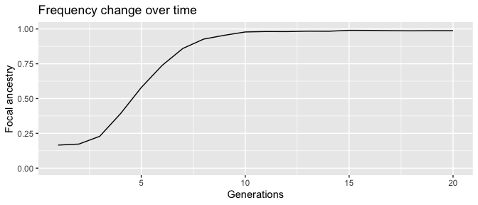

```r
ggplot(opt_res$results,
       aes(x = t, y = freq_focal_ancestry)) +
  geom_line() +
  ylim(0, 1) +
  ggtitle("Frequency change over time") +
  xlab("Generations") +
  ylab("Focal ancestry") +
  ggtitle("Frequency change over time") +
  xlab("Generations") +
  ylab("Focal ancestry")
```

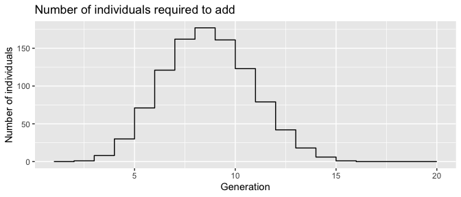

```r
ggplot(opt_res$curve,
       aes(x = t, y = put)) +
  geom_step() +
  ggtitle("Number of individuals required to add") +
  xlab("Generation") +
  ylab("Number of individuals")
```

We can do a similar analysis for pulling as well:

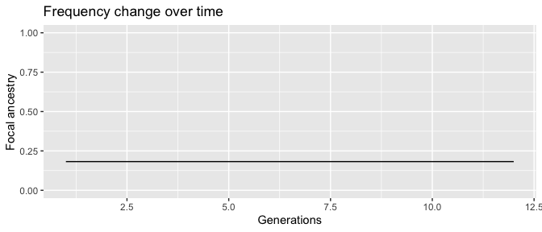

```r
opt_res <- optimize_adaptive(target_frequency = 0.99,
                             optimize_pull = 1000,
                             optimize_put = 0,
                             num_generations = 20,
                             starting_freq = 0.2,
                             initial_population_size = 100)
ggplot(opt_res$results,
       aes(x = t, y = freq_focal_ancestry)) +
  geom_line() +
  ylim(0, 1) +
  ggtitle("Frequency change over time") +
  xlab("Generations") +
  ylab("Focal ancestry")
```

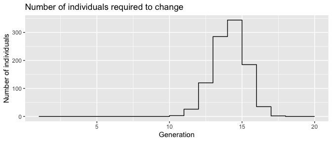

```r
ggplot(opt_res$curve,
       aes(x = t, y = pull)) +
  geom_step() +
    ggtitle("Number of individuals required to change") +
  xlab("Generation") +
  ylab("Number of individuals")
```

As before, pulling does not move the needle. But if we also add a little bit of putting, we find a much better solution:

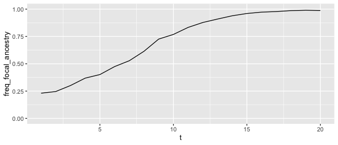

```r
opt_res <- optimize_adaptive(target_frequency = 0.99,
                             optimize_pull = 1000,
                             optimize_put = 100,
                             num_generations = 20,
                             starting_freq = 0.2,
                             initial_population_size = 100)
ggplot(opt_res$results,
       aes(x = t, y = freq_focal_ancestry)) +
  geom_line() +
  ylim(0, 1)
```

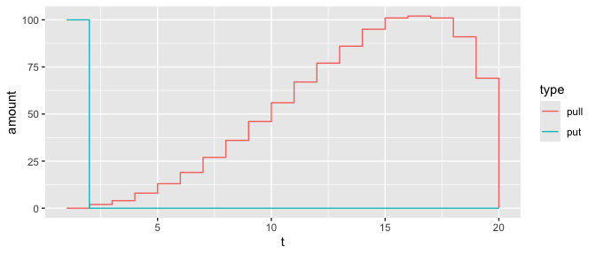

```r
opt_res$curve %>%
  tidyr::pivot_longer(names_to = "type", values_to = "amount", -t) %>%
  ggplot(aes(x = t, y = amount, col = type)) +
    geom_step()
```

# Underlying genetic model

By default, simRestore uses a very fast, but also very simplistic, representation of the underlying genetics, where a mating event simply results in an averaging of the ancestries of the two parents, without considering recombination. For the typical short timescales over which management strategies unfold, this is a safe approximation to make. However, for those that require additional genetic insight, simRestore includes an underlying genetics model that explicitly models recombination, which is based on simulations of the packages GenomeAdmixR and junctions. A local transition in ancestry along a chromosome was coined ‘junction’ by Fisher in 1954, and this more complex genetic model keeps track of new junctions that are formed. This introduces a larger degree of variation in outcomes, but on average results are highly similar:

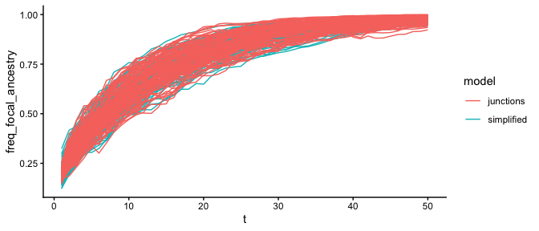

```r
sim_pop <- simulate_policy(initial_population_size = 100,
                           num_generations = 50,
                           put = 10,
                           starting_freq = 0.2,
                           genetic_model = "point",
                           num_replicates = 100,
                           K = 400)

sim_pop2 <- simulate_policy(initial_population_size = 100,
                            num_generations = 50,
                            put = 10,
                            starting_freq = 0.2,
                            genetic_model = "junctions",
                            num_replicates = 100,
                            K = 400)
# prepare data frame for plotting:
to_plot1 <- sim_pop$results
to_plot1$model <- "simplified"
to_plot2 <- sim_pop2$results
to_plot2$model <- "junctions"
to_plot2$replicate <- to_plot2$replicate + 100
to_plot <- rbind(to_plot1, to_plot2)

# plot all replicates:
ggplot(to_plot,
       aes(x = t, y = freq_focal_ancestry, col = model, group = replicate)) +
  geom_line() +
  # scale_color_brewer(type = "qual") +
  theme_classic()
```

[output not shown]

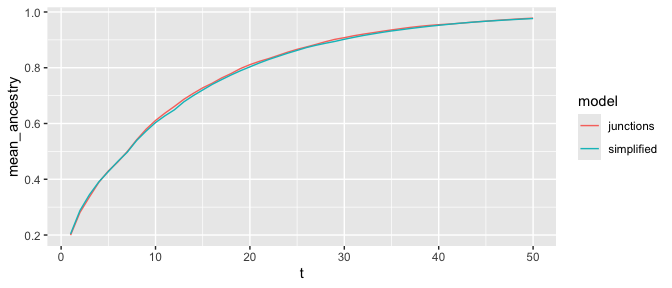

```r
# summarise across replicates:
to_plot %>%
  group_by(t, model) %>%
  summarise("mean_ancestry" = mean(freq_focal_ancestry)) %>%
  ggplot(aes(x = t, y = mean_ancestry, col = model)) +
    geom_line()
```